# Assignment 12

Brian Roepke

Nov 29, 2020

# NER and Topic Modeling

```r
# Basic libraries
library(ggplot2)
library(dplyr)
library(tidyverse)

# Text Mining and NLP Libraries
library(spacyr)
library(tm)
library(tidytext)
library(SnowballC)
library(stringr)
library(topicmodels)
library(textstem)

# date/time library
library(lubridate)
```

```r
spacy_initialize(model = "en_core_web_sm", condaenv="DATA104")
```

```
## successfully initialized (spaCy Version: 2.3.2, language model: en_core_web_sm)
```

```
## (python options: type = "condaenv", value = "DATA104")
```

## Data Loading

```r
df <- read.csv("news_groups.csv")
```

## Transformations

- Add text_len to capture the length of each document (eg: text field)
- Add doc_id with values ‘doc_id’. Example: row 1, 2 should have doc_id = doc1 , doc2, doc3 …. docN.

```r
# convert dataframe to tibble
tidy_df <- as_tibble(df$content)

# the text is itself a dataframe? modify the text column to pull out the text value
tidy_df <- tidy_df %>%
  mutate(text =  tidy_df$value)  %>%
  select(-value)
```

```r
tidy_df = tidy_df %>%
  mutate(text_len = str_count(text))
```

```r
# convert to TIF standard required by spacy
tidy_df = tidy_df %>%
  mutate(doc_id = paste0("doc", row_number())) %>%
  select(doc_id, everything())
head(tidy_df)
```

| doc_id | text | text_len |
| --- | --- | --- |
| doc1 | From: jlevine@rd.hydro.on.ca (Jody Levine)\nSubject: Re: Drinking and Riding (eww, gross)\nOrganization: Ontario Hydro - Research Division\nLines: 16\n\nIn article MJMUISE@1302.watstar.uwaterloo.ca (M… | 889 |
| doc2 | From: gharriso@hpcc01.corp.hp.com (Graeme Harrison)\nSubject: Re: Used Bikes, East vs. West Coasts\nOrganization: the HP Corporate notes server\nLines: 16\n\n/ hpcc01:rec.motorcycles / groverc@gold.gv… | 890 |
| doc3 | From: charlie@elektro.cmhnet.org (Charlie Smith)\nSubject: Re: looking for a maintenance manual for Honda CB 360\nOrganization: Why do you suspect that?\nLines: 19\n\nIn article buffalo@wam.umd.edu (D… | 968 |
| doc4 | From: mmanning@icomsim.com (Michael Manning)\nSubject: Re: Bikes And Contacts\nOrganization: Icom Simulations\nLines: 30\n\nIn article \nmpmena@skcla.monsanto.com writes:\n\n> Michael (Manning)...Must… | 1103 |
| doc5 | From: infante@acpub.duke.edu (Andrew Infante)\nSubject: Re: Definition of "two up"?\nDistribution: usa\nOrganization: Duke University; Durham, N.C.\nLines: 24\nNntp-Posting-Host: north1.acpub.duke.edu… | 978 |
| doc6 | From: mjs@sys.uea.ac.uk (Mike Sixsmith)\nSubject: Re: Looking for Women's Motorcycle Helmet\nOrganization: University of East Anglia\nDistribution: ba\nLines: 19\n\nlisa@alex.com (Lisa Rowlands) write… | 791 |

## Summary Stats and Structure

Output summary statics and discuss the shape of the dataset along with the text_len statistics and outliers.

```r
str(tidy_df)
```

```
## tibble [1,794 × 3] (S3: tbl_df/tbl/data.frame)
##  $ doc_id  : chr [1:1794] "doc1" "doc2" "doc3" "doc4" ...
##  $ text    : chr [1:1794] "From: jlevine@rd.hydro.on.ca (Jody Levine)\nSubject: Re: Drinking and Riding (eww, gross)\nOrganization: Ontari"| __truncated__ "From: gharriso@hpcc01.corp.hp.com (Graeme Harrison)\nSubject: Re: Used Bikes, East vs. West Coasts\nOrganizatio"| __truncated__ "From: charli…
##  $ text_len: int [1:1794] 889 890 968 1103 978 791 820 1248 976 926 ...
```

```r
tidy_df %>%
  select(text, text_len) %>%
  summary()
```

```
##      text              text_len
##  Length:1794        Min.   :  171
##  Class :character   1st Qu.:  778
##  Mode  :character   Median : 1201
##                     Mean   : 1679
##                     3rd Qu.: 1936
##                     Max.   :36272
```

- **text**: Length represents the number of observations, `1,794` in this dataset.
- **text_len**: The character count of the entries for each observation. A min of 171 with a max of 36,272. Using the 3rd Quartile, most of the values in this fall under 2,000 characters.

```r
head(tidy_df)
```

| doc_id | text | text_len |
| --- | --- | --- |
| doc1 | From: jlevine@rd.hydro.on.ca (Jody Levine)\nSubject: Re: Drinking and Riding (eww, gross)\nOrganization: Ontario Hydro - Research Division\nLines: 16\n\nIn article MJMUISE@1302.watstar.uwaterloo.ca (M… | 889 |
| doc2 | From: gharriso@hpcc01.corp.hp.com (Graeme Harrison)\nSubject: Re: Used Bikes, East vs. West Coasts\nOrganization: the HP Corporate notes server\nLines: 16\n\n/ hpcc01:rec.motorcycles / groverc@gold.gv… | 890 |
| doc3 | From: charlie@elektro.cmhnet.org (Charlie Smith)\nSubject: Re: looking for a maintenance manual for Honda CB 360\nOrganization: Why do you suspect that?\nLines: 19\n\nIn article buffalo@wam.umd.edu (D… | 968 |
| doc4 | From: mmanning@icomsim.com (Michael Manning)\nSubject: Re: Bikes And Contacts\nOrganization: Icom Simulations\nLines: 30\n\nIn article \nmpmena@skcla.monsanto.com writes:\n\n> Michael (Manning)...Must… | 1103 |
| doc5 | From: infante@acpub.duke.edu (Andrew Infante)\nSubject: Re: Definition of "two up"?\nDistribution: usa\nOrganization: Duke University; Durham, N.C.\nLines: 24\nNntp-Posting-Host: north1.acpub.duke.edu… | 978 |
| doc6 | From: mjs@sys.uea.ac.uk (Mike Sixsmith)\nSubject: Re: Looking for Women's Motorcycle Helmet\nOrganization: University of East Anglia\nDistribution: ba\nLines: 19\n\nlisa@alex.com (Lisa Rowlands) write… | 791 |

## Outliers Analysis and Removal

visualization: show histogram and boxplot to better visualize outliers.

Create an outliers data frame. Refer to: https://www.statsandr.com/blog/outliers-detection-in-r/#histogram Decide which outliers (if any) should be removed from your analysis, by inspecting some of the contents. You can use the c() function to display the entire contents of the text.

```r
summary(tidy_df$text_len)
```

```
##    Min. 1st Qu.  Median    Mean 3rd Qu.    Max.
##     171     778    1201    1679    1936   36272
```

### Text Length Distribution

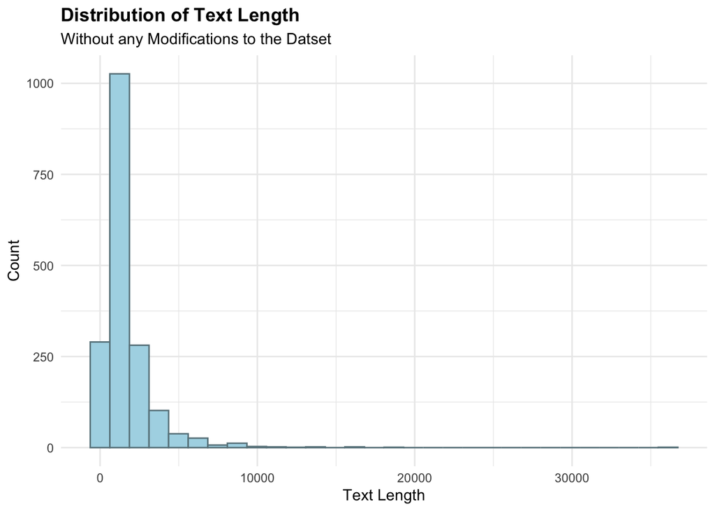

```r
ggplot(tidy_df) +
  aes(x = text_len) +
  geom_histogram(bins = 30L, fill = "lightblue", color = "lightblue4") +
  theme_minimal() +
  theme(plot.title = element_text(face = "bold")) +
  labs(
    x = "Text Length", y = "Count",
    title = "Distribution of Text Length",
    subtitle = "Without any Modifications to the Datset"
  )
```

### Text Length Box Plot

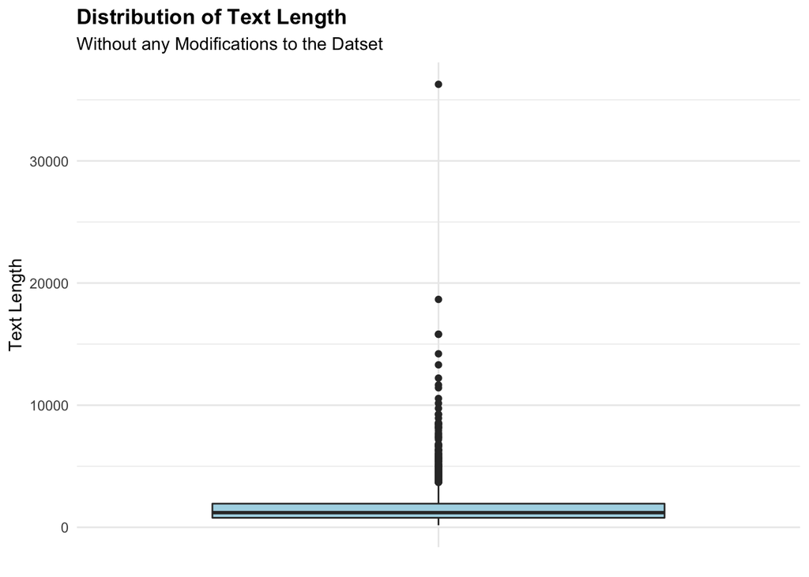

```r
ggplot(tidy_df) +
  aes(x = "", y = text_len) +
  geom_boxplot(fill = "lightblue") +
  theme_minimal() +
  theme(plot.title = element_text(face = "bold")) +
  labs(
    x = NULL, y = "Text Length",
    title = "Distribution of Text Length",
    subtitle = "Without any Modifications to the Datset"
  )
```

The box plot shows us a similar view, with a number of outliers beyond the inner-quartile. and a high concentraion around `~1,500`.

#### Determine Outliers

We can determine which rows represent outliers and remove those from our dataset.

```r
out <- boxplot.stats(tidy_df$text_len)$out
out_ind <- which(tidy_df$text_len %in% c(out))
out_ind
```

```
##   [1]   24   59   89   90  290  322  408  434  446  545  605  610  620  638  644
##  [16]  657  658  674  675  762  765  797  819  825  839  844  848  865  892  893
##  [31]  909  921  941 1000 1020 1024 1026 1035 1039 1041 1055 1102 1112 1121 1122
##  [46] 1199 1200 1203 1214 1222 1235 1236 1237 1239 1243 1247 1260 1266 1297 1299
##  [61] 1304 1306 1312 1315 1319 1321 1336 1341 1344 1347 1352 1357 1389 1392 1394
##  [76] 1424 1432 1436 1444 1445 1460 1464 1465 1467 1468 1469 1470 1495 1506 1515
##  [91] 1517 1522 1541 1543 1546 1554 1557 1564 1566 1579 1582 1592 1595 1604 1605
## [106] 1610 1615 1629 1635 1642 1648 1649 1655 1657 1662 1672 1677 1688 1689 1691
## [121] 1696 1699 1701 1703 1705 1720 1743 1748 1761 1765 1768 1785
```

### Remove all outliers

```r
sprintf("Original Rows = %s", nrow(tidy_df))
```

```
## [1] "Original Rows = 1794"
```

```r
sprintf("Number of Outliers = %s", length(out_ind))
```

```
## [1] "Number of Outliers = 132"
```

```r
tidy_df <- tidy_df[-out_ind, ]
sprintf("New Number of Rows = %s", nrow(tidy_df))
```

```
## [1] "New Number of Rows = 1662"
```

After removing the outliers from the dataset, we’re left with 1,662 total observations. We can examine the summary stats and box plot again.

```r
summary(tidy_df$text_len)
```

```
##    Min. 1st Qu.  Median    Mean 3rd Qu.    Max.
##   171.0   744.2  1131.0  1313.6  1710.8  3673.0
```

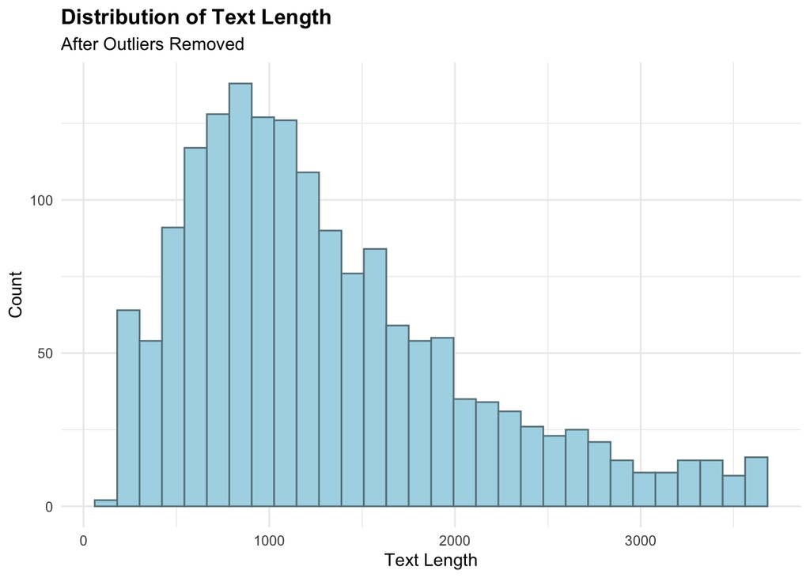

```r
ggplot(tidy_df) +
  aes(x = text_len) +
  geom_histogram(bins = 30L, fill = "lightblue", color="lightblue4") +
  theme_minimal() +
  theme(plot.title = element_text(face = "bold")) +
  labs(
    x = "Text Length", y = "Count",
    title = "Distribution of Text Length",
    subtitle = "After Outliers Removed"
  )
```

After removing outliers, the shape of the histogram is still right-skewed, but not as dramatic as before.

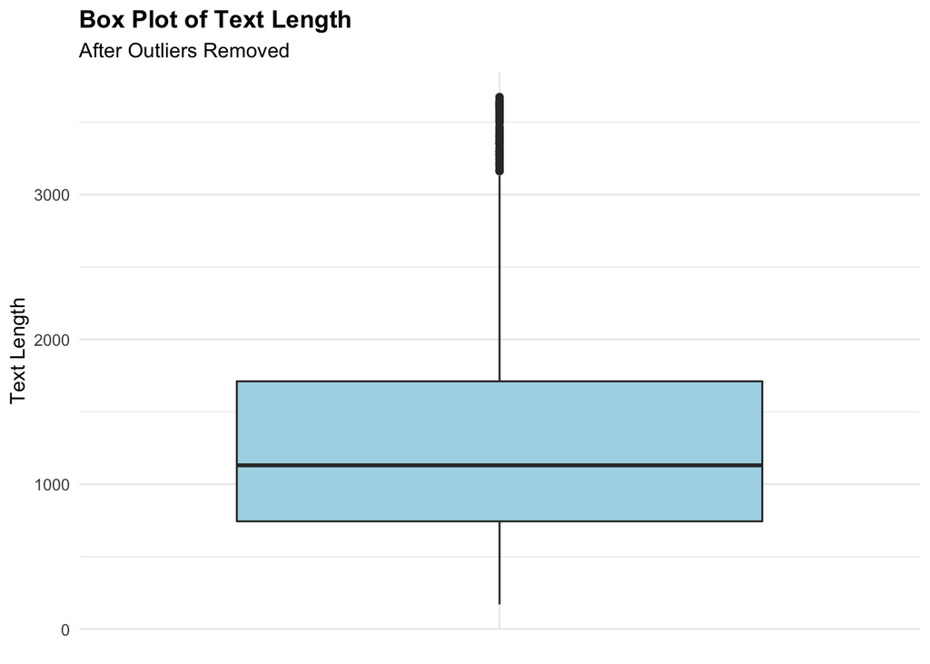

```r
ggplot(tidy_df) +
  aes(x = "", y = text_len) +
  geom_boxplot(fill = "lightblue") +
  theme_minimal() +
  theme(plot.title = element_text(face = "bold")) +
  labs(
    x = NULL, y = "Text Length",
    title = "Box Plot of Text Length",
    subtitle = "After Outliers Removed"
  )
```

The boxplot also shows a much less compressed view of the inner-quartile range of data. There are still some outliers plotted but extreme values have been removed.

# NER

Conduct Named entity recognition. Do not perform pre-processing prior. Algorithms and tools such as spaCy often rely on semantic language structures in order to identify entities (eg: punctuation, capitalization for pronouns, etc.) Generally NER requires tokenization and pos tagging, however the spacyR library automatically performs this for you.

## Sample the Data to a Smaller Subset.

Using a random see (1234), to provide consistent results between runs.

```r
# sample smaller set of docs
set.seed(1234)
sample_df = tidy_df %>%
  sample_n(1000)
```

## Add Named Entity Types

Using the spacyR library.

```r
# parse name-entities
parsedtxt <- spacy_parse(sample_df, type = "all")

ner = entity_extract(parsedtxt)  %>%
  arrange(entity_type)
```

### Part of Speech Tagging Counts

Display the different parts of speech identified as well as the counts of each.

```r
# Parts of Speech Tagging Counts
parsedtxt %>%
  group_by(pos) %>%
  summarise(count = n(), .groups = "keep") %>%
  arrange(desc(count))
```

| pos | count |
| --- | --- |
| PUNCT | 49860 |
| NOUN | 35980 |
| SPACE | 33307 |
| PROPN | 33114 |
| VERB | 23598 |
| DET | 21365 |
| ADP | 19660 |
| PRON | 14416 |
| AUX | 12420 |
| ADJ | 11697 |

[output cut: 8 more lines]

### Entity Type Counts

Display the counts of each of the Entity Types extracted from the corpus.

```r
ner %>%
  group_by(entity_type) %>%
  summarise(count = n(), .groups = "keep") %>%
  arrange(desc(count))
```

| entity_type | count |
| --- | --- |
| PERSON | 5433 |
| ORG | 3575 |
| GPE | 1527 |
| NORP | 834 |
| WORK | 430 |
| PRODUCT | 236 |
| LOC | 141 |
| FAC | 106 |
| EVENT | 56 |
| LANGUAGE | 29 |

[output cut: 1 more lines]

### Entity Types

The following 11 types of Entities were extracted, the following are their definitions as well as examples of each.

https://spacy.io/api/annotation

- Entities of type PERSON which are People, including fictional.
- Entities of type NORP which are Nationalities or religious or political groups.
- Entities of type ORG which are Companies, agencies, institutions, etc.
- Entities of type GPE which are geo-political entities such as city, state/province, and country
- Entities of type PRODUCT which are products
- Entities of type WORK OF ART which are Titles of books, songs, etc.
- Entities of type LOC which are Non-GPE locations, mountain ranges, bodies of water.
- Entities of type FAC which are Buildings, airports, highways, bridges, etc.
- Entities of type EVENT which are Named hurricanes, battles, wars, sports events, etc.
- Entities of type LAW which are Named documents made into laws.
- Entities of type LANGUAGE which are Any named language.

```r
entities<- c("PERSON", "NORP", "ORG", "GPE", "PRODUCT", "WORK",
             "LOC", "FAC", "EVENT", "LAW", "LANGUAGE")

for (e in entities){
  ner %>%
    mutate(type=e) %>%
    filter(entity_type == e) %>%
    group_by(entity, type) %>%
    summarize(count = n(), .groups = "keep") %>%
    arrange(desc(count)) %>%
    print()

}
```

```
## # A tibble: 2,374 x 3
## # Groups:   entity, type [2,374]
##    entity                  type   count
##    <chr>                   <chr>  <int>
##  1 Jesus                   PERSON   184
##  2 Sun                     PERSON    48
##  3 Mary                    PERSON    43
##  4 Nntp_-_Posting_-_Host_: PERSON    42
##  5 Chris_BeHanna           PERSON    32
##  6 God                     PERSON    26
##  7 Paul                    PERSON    26
##  8 Morris                  PERSON    22
##  9 Ed                      PERSON    21
## 10 Alomar                  PERSON    17
## # … with 2,364 more rows
## # A tibble: 180 x 3
## # Groups:   entity, type [180]
##    entity     type  count
##    <chr>      <chr> <int>
##  1 Christians NORP    145
##  2 Christian  NORP    121
##  3 Jewish     NORP     91
##  4 Catholic   NORP     25
##  5 Indians    NORP     25
##  6 Jews       NORP     24
##  7 Romans     NORP     16
##  8 christians NORP     15
##  9 Catholics  NORP     14
## 10 DL         NORP     13
## # … with 170 more rows
## # A tibble: 1,565 x 3
## # Groups:   entity, type [1,565]
##    entity       type  count
##    <chr>        <chr> <int>
##  1 Cubs         ORG      63
##  2 Braves       ORG      59
##  3 DoD          ORG      58
##  4 BMW          ORG      57
##  5 Christianity ORG      54
##  6 Christ       ORG      41
```

[output cut: 109 more lines]

```
## 11 "Major_League_Stat_Disk"             LAW       1
## 12 "NEC_\t  _1991"                      LAW       1
## 13 "the_Chapter_One"                    LAW       1
## 14 "the_Crucifxition_of_Our_Lord"       LAW       1
## 15 "Yamaha_Seca"                        LAW       1
## # A tibble: 6 x 3
## # Groups:   entity, type [6]
##   entity  type     count
##   <chr>   <chr>    <int>
## 1 English LANGUAGE    17
## 2 Hebrew  LANGUAGE     5
## 3 english LANGUAGE     3
## 4 French  LANGUAGE     2
## 5 German  LANGUAGE     1
## 6 Latin   LANGUAGE     1
```

# Topic Modeling

Topic Modeling performed using LDA.

- Text pre-processing
- Case normalization (lower-case)
- Remove emails, stop words, punctuation, numbers, new lines, single quotes
- Lemmatization
- Include visualizations of topics and word groupings
- Assess the model.

Do the topics and words make sense given visual inspection?

## Preprocessing

```r
corpus <- Corpus(VectorSource(sample_df$text))
```

### Before cleaning

```r
inspect(corpus[1:5])
```

```
## <<SimpleCorpus>>
## Metadata:  corpus specific: 1, document level (indexed): 0
## Content:  documents: 5
##
## [1] From: teama@bucknell.edu (meyers@bucknell.edu)\nSubject: Doug Sturm\nOrganization: Bucknell University, Lewisburg, PA\nLines: 3\n\nIs anyone familiar with Doug Sturm?\n\nIf so, please post what you think.\n
## [2] From: gwittt@alleg.edu (Tom Gwitt)\nSubject: Re: Mel Hall\nOrganization: Allegheny College\nLines: 11\n\nIn article <1993Apr17.212119.13901@coe.montana.edu> warped@cs.montana.edu  \n(Doug Dolven) writes:\n> \n> Has anyone heard anything about Mel Hall this season?  I'd heard he  \nwasn't\n> w…
## [3] From: jbrown@stein.u.washington.edu (Jeffery Brown)\nSubject: Re: Early BBDDD Returns?\nOrganization: University of Washington, Seattle\nLines: 17\nNNTP-Posting-Host: stein.u.washington.edu\n\nIn article <1993Apr16.073051.9160@news.cs.brandeis.edu> st902415@pip.cc.brandeis.edu writes:\n>Just …
## [4] From: jaeastman@anl.gov (Jeff Eastman)\nSubject: Re: cubs & expos roster questions\nOrganization: Argonne National Laboratory\nLines: 23\n\nIn article <15APR199312304021@pavo.concordia.ca>, m_klein@pavo.concordia.ca\n(CorelMARK!) wrote:\n> \n> In article <0096B0F0.C5DE05A0@Msu.oscs.montana.ed…
## [5] From: rjh@allegra.att.com (Robert Holt)\nSubject: Re: ALL-TIME BEST PLAYERS\nOrganization: AT&T Bell Laboratories, Murray Hill, NJ\nLines: 78\n\nIn article <1993Apr15.162313.154828@ns1.cc.lehigh.edu> jsr2@ns1.cc.lehigh.edu (JOHN STEPHEN RANDOLPH) writes:\n>In article <1993Apr13.115313.17986@b…
```

### Remove E-mails

```r
corpus <- tm_map(
  corpus,
  content_transformer(
    function(x) str_replace_all(x,"[a-zA-Z0-9_.+-]+@[a-zA-Z0-9-]+\\.[a-zA-Z0-9-.]+", "")
    )
)
```

### Remove URLs

```r
corpus <- tm_map(
  corpus,
  content_transformer(
    function(x) gsub("http[[:alnum:][:punct:]]*", "", x)
    )
)
```

### Remove New Line and Tab Escape Sequences

```r
# remove new lines and tabs
corpus <- tm_map(
  corpus,
  content_transformer(
    function(x) gsub("\\n", " ", x)
    )
)
corpus <- tm_map(
  corpus,
  content_transformer(
    function(x) gsub("\\t", " ", x)
    )
)
```

### Transform all Text to Lowercase

```r
# force all to lowercase
corpus <- tm_map(corpus, tolower)
```

### Remove Common Header Information from the Discussion Posts

```r
# get rid of the useless newsgroup stuff
corpus <- tm_map(
  corpus,
  content_transformer(
    function(x) gsub("from:", " ", x)
    )
)
corpus <- tm_map(
  corpus,
  content_transformer(
    function(x) gsub("subject:", " ", x)
    )
)
corpus <- tm_map(
  corpus,
  content_transformer(
    function(x) gsub("re:", " ", x)
    )
)
```

### Remove Punctuation, White Space and Numbers

```r
corpus <- tm_map(corpus, removePunctuation)  # remove punctuation
corpus <- tm_map(corpus, removeNumbers)      # remove numbers
corpus <- tm_map(corpus, stripWhitespace)    # remove white space
```

### Remove Stop Words

```r
# stop and custom stop
corpus <- tm_map(corpus, removeWords, c(stopwords('english')))
```

### Perform Lemmatization

```r
corpus <- tm_map(corpus, lemmatize_strings) # lemmatizaton
```

### Remove Words that Aren’t Helpful for Topic Modeling

Custom list of words generated upon performing the topic modeling. These were frequently appeared but do not add a lot of context to topic identification, or appear so frequently, such as `University`, that they are in every topic.

```r
corpus <- tm_map(corpus, removeWords, c("line", "write",
                                        "article", "get", "good", "one",
                                        "year", "nntppostinghost", "can",
                                        "say", "will", "know", "may",
                                        "like", "see", "time", "just",
                                        "make", "think", "thing", "way",
                                        "come", "much", "want", "take",
                                        "ive", "day", "first", "xnewsreader",
                                        "university", "also", "people", "use",
                                        "organization", "dod", "distribution"))
```

### Corpus After Cleaning

```r
inspect(corpus[1:5])
```

```
## <<SimpleCorpus>>
## Metadata:  corpus specific: 1, document level (indexed): 0
## Content:  documents: 5
##
## [1] doug sturm  bucknell  lewisburg pa  anyone familiar doug sturm please post
## [2] tom gwitt mel hall  allegheny college   doug dolven  anyone hear anything mel hall season id hear wasnt yankee happen japan play baseball tom gwitt
## [3] jeffery brown early bbddd return   washington seattle   steinuwashingtonedu    curious anyone start standout early season bb ddd  tater jack morris serve griffey young  atbat  go foot remember right ill check scorecard home  thats long far kingdome  stand five game weak show despite promise t…
## [4] jeff eastman cub expos roster question  argonne national laboratory   corelmark      today cub activate p mike harkey dl move  room harkey  delino deshields john wetteland expos dl thank anyone  give info ken cal poly pomona wetteland dl effective march something  rick cub send boskie iowa  r…
## [5] robert holt alltime  player  att bell laboratory murray hill nj   john stephen randolph   aprbsuucs   recently work project determine great player respective postions source total baseball james historical abstract ballplayer biography word mouth bias opinion feel free comment suggest flame w…
```

### Document Term Matrix Creation

```r
dtm <- DocumentTermMatrix(corpus, control = list(minWordLength = 5,
                removeNumbers=FALSE, removePunctuation=FALSE,
                removeStopwords=FALSE,  stemWords=FALSE, stripWhitespace=FALSE))
```

```r
inspect(dtm)
```

```
## <<DocumentTermMatrix (documents: 1000, terms: 11835)>>
## Non-/sparse entries: 66383/11768617
## Sparsity           : 99%
## Maximal term length: 78
## Weighting          : term frequency (tf)
## Sample             :
##      Terms
## Docs  believe bike christian even game give god last look question
##   170       0    0         0    1    0    3   0    1    0        0
##   280       6    0         1    2    0    3  13    1    0        0
##   496       2    0         2    0    0    2   2    0    0        0
##   593       0    0         0    1    0    1   0    0    4        0
##   605       0    7         0    1    0    0   0    0    3        3
##   670       1    0         0    0    1    0   0    1    3        1
##   753       1    0         0    0    1    1   0    0    2        0
##   830       0    0         0    2    0    4   6    0    0        2
##   854       0    2         0    1    0    2   0    1    0        0
##   985       0    7         0    0    0    0   0    0    2        0
```

```r
# check for rows with all 0's
zero_row <- sample_df[rowSums(as.matrix(dtm)) == 0, ]
dim(zero_row)
```

```
## [1] 0 3
```

```r
sel_idx <- rowSums(as.matrix(dtm)) > 0
dtm <- dtm[sel_idx, ]
dim(dtm)
```

```
## [1]  1000 11835
```

## Latent Dirichlet Allocation (LDA)

Is an unsupervised classification method designed for text data. Rather than relying on labeled (eg: hand-coded data sets), it is a probabilistic topic model that uses statistical algorithms to analyze words in raw text documents, to uncover thematic structure of the both the corpus and individual documents.

### Find the best k - the Elbow Method

The basic idea behind partitioning methods, such as k-means clustering, is to define clusters such that the total intra-cluster variation [or total within-cluster sum of square (WSS)] is minimized. The total WSS measures the compactness of the clustering and we want it to be as small as possible.

The Elbow method looks at the total WSS as a function of the number of clusters: One should choose a number of clusters so that adding another cluster doesn’t improve much better the total WSS.

https://www.datanovia.com/en/lessons/determining-the-optimal-number-of-clusters-3-must-know-methods/

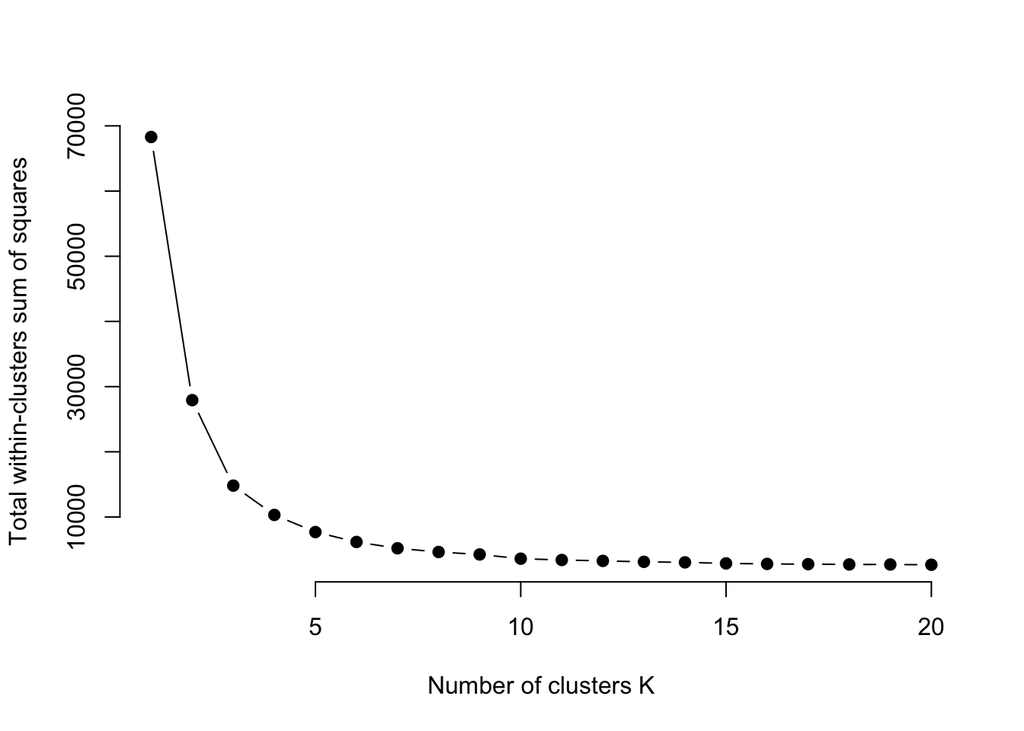

```r
mat <- as.matrix (weightTfIdf(dtm) )

# normalize the TfIdf scores by euclidean distance.
scaled_data  <- dist(mat, method = "euclidean")

k.max <- 20
data <- scaled_data
wss <- sapply(1:k.max,
  function(k){kmeans(data, k, nstart=50,iter.max = 15)$tot.withinss})

plot(1:k.max, wss,
     type="b", pch = 19, frame = FALSE,
     xlab="Number of clusters K",
     ylab="Total within-clusters sum of squares")
```

Looking at the plot it looks like either **3** or **5 clusters** is our optimal value. We can plot both to see which one give us the best results.

## LDA

```r
lda <- LDA(dtm, k = 5, control = list(seed = 1234))
lda
```

```
## A LDA_VEM topic model with 5 topics.
```

### Per-Topic-Per-Word Probabilities (Beta)

```r
# beta (per-term-per-topic)
topics <- tidy(lda, matrix = "beta")
topics %>%
  arrange(term, -beta)  %>%
  head()
```

| topic | term | beta |
| --- | --- | --- |
| 1 | aaa | 7.487681e-04 |
| 2 | aaa | 9.509503e-05 |
| 3 | aaa | 4.415440e-21 |
| 4 | aaa | 4.238545e-29 |
| 5 | aaa | 7.602718e-99 |
| 1 | aaamajors | 5.372406e-05 |

### Per-Document-Per-Topic Probabilities (Gamma)

```r
tidy(lda, matrix = "gamma")  %>%
  arrange(document, -gamma)  %>%
  head()
```

| document | topic | gamma |
| --- | --- | --- |
| 1 | 2 | 0.989518148 |
| 1 | 3 | 0.002620463 |
| 1 | 5 | 0.002620463 |
| 1 | 4 | 0.002620463 |
| 1 | 1 | 0.002620463 |
| 10 | 3 | 0.564656892 |

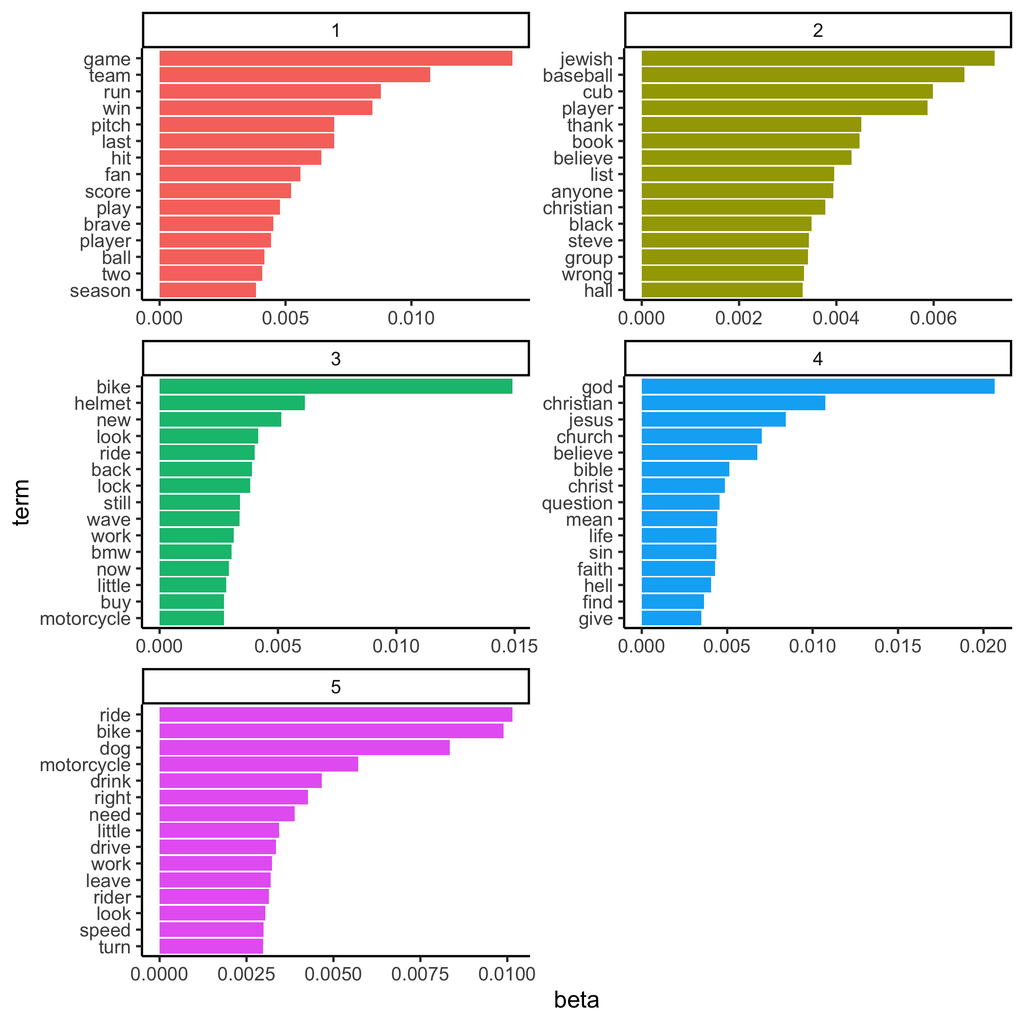

```r
top_terms <- topics %>%
  group_by(topic) %>%
  top_n(15, beta) %>%
  ungroup() %>%
  arrange(topic, -beta)

top_terms %>%
  mutate(term = reorder_within(term, beta, topic)) %>%
  ggplot(aes(beta, term, fill = factor(topic))) +
    geom_col(show.legend = FALSE) +
    facet_wrap(~ topic, scales = "free", ncol=2) +
    theme_classic(base_size = 20) +
    scale_y_reordered()
```

Starting with the slightly higher number of **5**, it does appear that there is heavy overlap with a couple of the topics. We can re-run this with the other setting from the elbow plot, **3**.

### High Level Groupings

```r
lda2 <- LDA(dtm, k = 3, control = list(seed = 1234))
lda2
```

```
## A LDA_VEM topic model with 3 topics.
```

```r
# beta (per-term-per-topic)
topics2 <- tidy(lda2, matrix = "beta")
topics2 %>%
  arrange(term, -beta)  %>%
  head()
```

| topic | term | beta |
| --- | --- | --- |
| 3 | aaa | 3.640586e-04 |
| 1 | aaa | 5.859026e-05 |
| 2 | aaa | 2.988217e-18 |
| 3 | aaamajors | 2.607456e-05 |
| 1 | aaamajors | 2.346192e-179 |
| 2 | aaamajors | 2.756238e-187 |

### Top-Level Topics

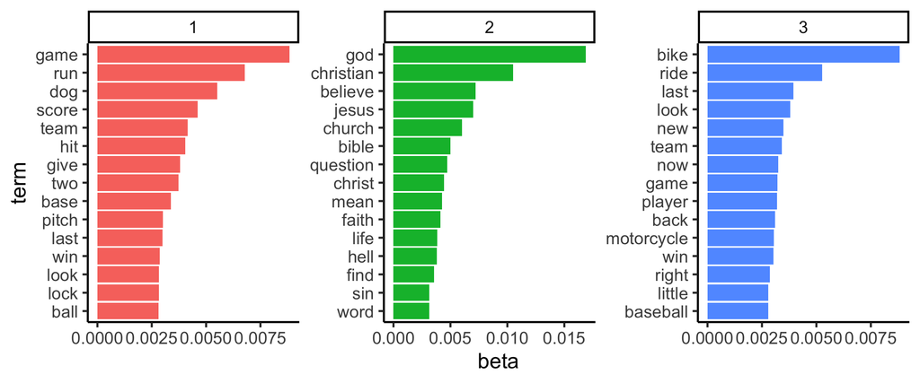

```r
top_terms2 <- topics2 %>%
  group_by(topic) %>%
  top_n(15, beta) %>%
  ungroup() %>%
  arrange(topic, -beta)

top_terms2 %>%
  mutate(term = reorder_within(term, beta, topic)) %>%
  ggplot(aes(beta, term, fill = factor(topic))) +
    geom_col(show.legend = FALSE) +
    facet_wrap(~ topic, scales = "free", ncol=3) +
    theme_classic(base_size = 20) +
    scale_y_reordered()
```

After reviewing the text from the **5** topics above, it appears that this data comes from **3** distinct discussion groups.

1. **Baseball** - game, run, score, team, hit, base, pitch, win, and ball are all solid indications that this is true.
2. **Religion** - god, christian, believe, jesus, church, bible, faith, sin are all words directed tied to religion and possible Christianity.
3. **Motorcycles** - bike, ride, motorcycle are all potential for the third grouping. But it’s possible that there are only two main groupings, and this is a sub grouping since we see terms from baseball falling into this as well.